# Coursera Practical Machine Learning Course Project

Koen Vermeulen

18-11-2019

## Introduction

Nowadays it is possible to collect a large amount of data about personal activity relatively inexpensively by using wearing devices. This project predicts the way of exersizing by using the data from accelometers on the belt, forearm, arm, and dumbell of 6 participants.

## Opening libraries

For the project a few libraries are being used.

```r
library(dplyr)
library(randomForest)
library(caret)
library(rpart)
```

## Downloading the data

```r
Train_Test_Raw <- read.csv("https://d396qusza40orc.cloudfront.net/predmachlearn/pml-training.csv")
Validation_Raw <- read.csv("https://d396qusza40orc.cloudfront.net/predmachlearn/pml-testing.csv")
dim(Train_Test_Raw)
dim(Validation_Raw)
str(Train_Test_Raw)
str(Validation_Raw)
```

[output not shown]

## Checking NAs & excluding NA columns & irrelevant columns

```r
NA_col <- as.data.frame(sapply(Train_Test_Raw, function(x) sum(is.na(x))))
NA_col
```

[output not shown]

After checking the NAs, it can be seen that there are columns rarely filled. They contain a lot of NA-values. Therefore we drop these NA-columns.

There are also some columns which are not relevant for predicting the outcome. These columns are being dropped as well.

We do this for the train / test set, but also for the validation set.

```r
Train_Test <- Train_Test_Raw[, colSums(is.na(Train_Test_Raw)) == 0]
classeTT <- Train_Test$classe
Train_Test <- select(Train_Test, -X, -user_name, -raw_timestamp_part_1, -raw_timestamp_part_2, -cvtd_timestamp)
train_test <- Train_Test[, sapply(Train_Test, is.numeric)]
train_test$classe <- classeTT

Validation <- Validation_Raw[, colSums(is.na(Validation_Raw)) == 0]
classeV <- Validation$classe
Validation <- select(Validation, -X, -user_name, -raw_timestamp_part_1, -raw_timestamp_part_2, -cvtd_timestamp)
validation <- Validation[, sapply(Validation, is.numeric)]
validation$classe <- classeV
```

## Setting seed & slicing data in train and test

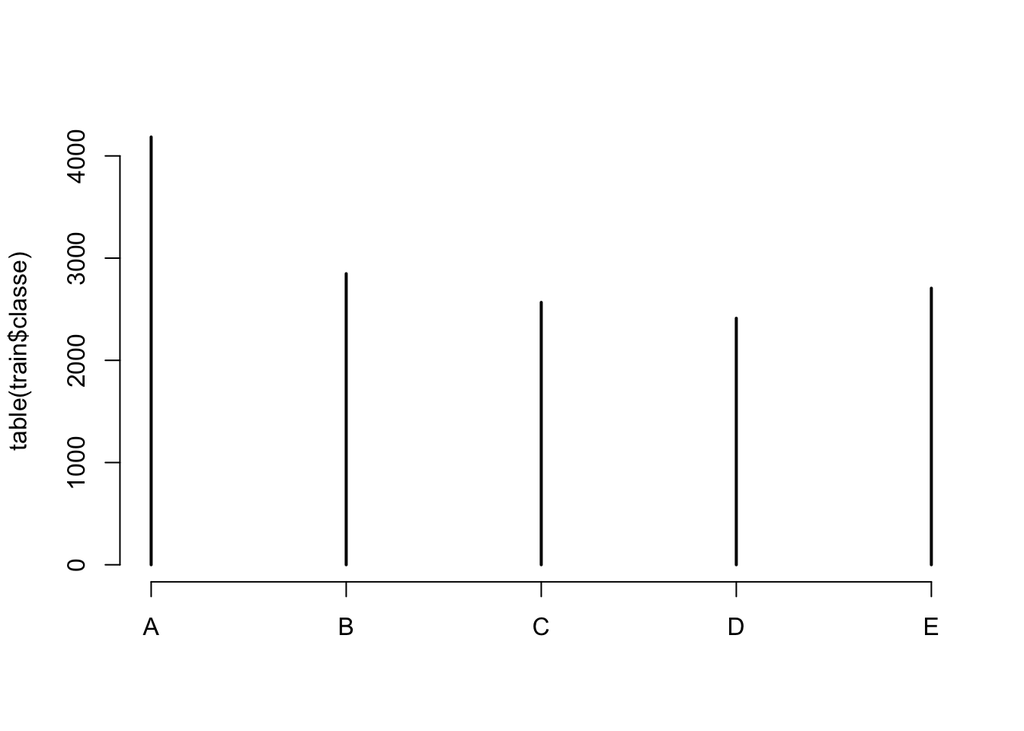

```r
set.seed(12321)
inTrain <- createDataPartition(train_test$classe, p = 0.75, list = FALSE)

train <- train_test[inTrain, ]
test <- train_test[-inTrain, ]

plot(table(train$classe))
```

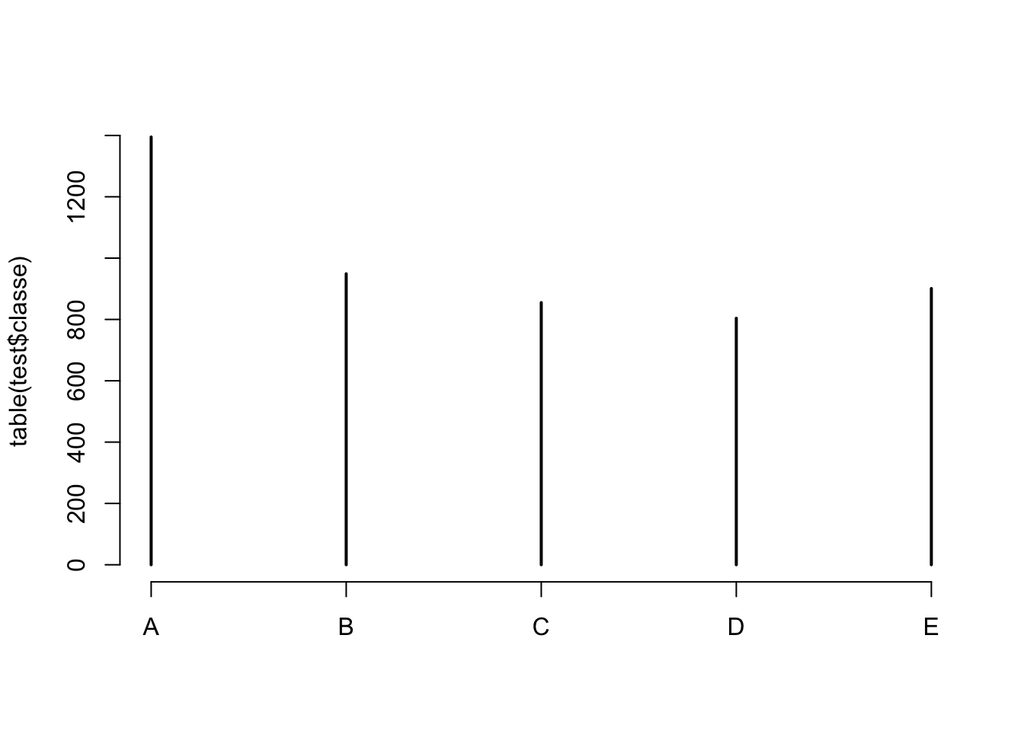

```r
plot(table(test$classe))
```

## Training randomforrest model

The predictive model used for activity recognition is a **Random Forest** algorithm because it automatically selects relevant and important predictors and is robust to correlated covariates & outliers in general. A **5-fold cross validation** is used when applying the algorithm.

```r
cv <- trainControl(method="cv", 5)
model <- train(classe ~ .,
               data = train,
               method = "rf",
               trControl = cv,
               ntree=250)
model
```

```
## Random Forest
##
## 14718 samples
##    53 predictor
##     5 classes: 'A', 'B', 'C', 'D', 'E'
##
## No pre-processing
## Resampling: Cross-Validated (5 fold)
## Summary of sample sizes: 11774, 11775, 11774, 11774, 11775
## Resampling results across tuning parameters:
##
##   mtry  Accuracy   Kappa
##    2    0.9927978  0.9908890
##   27    0.9970102  0.9962181
##   53    0.9956515  0.9944995
##
## Accuracy was used to select the optimal model using the largest value.
## The final value used for the model was mtry = 27.
```

## Testing the model

The performance of the model is calculated on the test data set.

```r
predict <- predict(model, test)
confusionMatrix(test$classe, predict)
```

```
## Confusion Matrix and Statistics
##
##           Reference
## Prediction    A    B    C    D    E
##          A 1395    0    0    0    0
##          B    4  945    0    0    0
##          C    0    1  854    0    0
##          D    0    0    1  803    0
##          E    0    0    0    1  900
##
## Overall Statistics
##
##                Accuracy : 0.9986
##                  95% CI : (0.9971, 0.9994)
##     No Information Rate : 0.2853
##     P-Value [Acc > NIR] : < 2.2e-16
##
##                   Kappa : 0.9982
##
##  Mcnemar's Test P-Value : NA
##
## Statistics by Class:
##
##                      Class: A Class: B Class: C Class: D Class: E
## Sensitivity            0.9971   0.9989   0.9988   0.9988   1.0000
## Specificity            1.0000   0.9990   0.9998   0.9998   0.9998
## Pos Pred Value         1.0000   0.9958   0.9988   0.9988   0.9989
## Neg Pred Value         0.9989   0.9997   0.9998   0.9998   1.0000
## Prevalence             0.2853   0.1929   0.1743   0.1639   0.1835
## Detection Rate         0.2845   0.1927   0.1741   0.1637   0.1835
## Detection Prevalence   0.2845   0.1935   0.1743   0.1639   0.1837
## Balanced Accuracy      0.9986   0.9990   0.9993   0.9993   0.9999
```

The accuracy of the model is 99.86%.

## Applying model

With this accuracy the model can be applied to the validation set.

```r
result <- predict(model, validation[, -length(names(validation))])
result
```

```
##  [1] B A B A A E D B A A B C B A E E A B B B
## Levels: A B C D E
```